# PS5 Assignment

Jaiden Shoel

2023-02-20

### Section 1: Load and check data

```r
#1
library(tidyverse)
#2
gap <- read_delim("gapminder.csv")
#3
nrow(gap)
```

```
## [1] 13055
```

```r
ncol(gap)
```

```
## [1] 25
```

```r
#4
sample_n(gap, 50)
```

```
## # A tibble: 50 × 25
##    iso3  name         iso2  region sub-r…¹ inter…²  time total…³ ferti…⁴ lifeE…⁵
##    <chr> <chr>        <chr> <chr>  <chr>   <chr>   <dbl>   <dbl>   <dbl>   <dbl>
##  1 TLS   Timor-Leste  TL    Asia   South-… <NA>     1975  6.29e5    5.19    35.1
##  2 MRT   Mauritania   MR    Africa Sub-Sa… Wester…  1987  1.88e6    6.07    58.7
##  3 SMR   San Marino   SM    Europe Southe… <NA>     1980  2.15e4   NA       NA
##  4 SOM   Somalia      SO    Africa Sub-Sa… Easter…  1963  2.94e6    7.26    38.2
##  5 TCA   Turks and C… TC    Ameri… Latin … Caribb…  2016  3.66e4   NA       NA
##  6 NRU   Nauru        NR    Ocean… Micron… <NA>     2004  9.90e3   NA       NA
##  7 PRK   Korea (Demo… KP    Asia   Easter… <NA>     1981  1.77e7    2.75    66.6
##  8 SMR   San Marino   SM    Europe Southe… <NA>     1981  2.18e4   NA       NA
##  9 MNP   Northern Ma… MP    Ocean… Micron… <NA>     1996  4.75e4   NA       NA
## 10 DEU   Germany      DE    Europe Wester… <NA>     2008  8.21e7    1.38    79.7
## # … with 40 more rows, 15 more variables: childMortality <dbl>,
## #   youthFemaleLiteracy <dbl>, youthMaleLiteracy <dbl>, adultLiteracy <dbl>,
## #   GDP_PC <dbl>, accessElectricity <dbl>, agriculturalLand <dbl>,
## #   agricultureTractors <dbl>, cerealProduction <dbl>, fertilizerHa <dbl>,
## #   co2 <dbl>, greenhouseGases <dbl>, co2_PC <dbl>, pm2.5_35 <dbl>,
## #   battleDeaths <dbl>, and abbreviated variable names ¹`sub-region`,
## #   ²`intermediate-region`, ³totalPopulation, ⁴fertilityRate, ⁵lifeExpectancy
```

Yes it looks ok.

### Section 2: Descriptive statistics

```r
#1
countries_iso3 <- gap %>% distinct(iso3) %>% nrow()
countries_iso2 <- gap %>% distinct(iso2) %>% nrow()
countries_name <- gap %>% distinct(name) %>% nrow()

countries_iso3
```

```
## [1] 253
```

```r
countries_iso2
```

```
## [1] 249
```

```r
countries_name
```

```
## [1] 250
```

There are 253 countries for iso3 codes, 249 for iso2 codes, and 250 for country names

2.) My prediction for why this may be is because there might be additional islands or pieces of land that are accounted for within the iso codes or names.

```r
#2a
names_iso2 <- gap %>%
  group_by(iso2) %>%
  summarize(num = n_distinct(name)) %>%
  arrange(desc(num))

names_iso2
```

```
## # A tibble: 249 × 2
##    iso2    num
##    <chr> <int>
##  1 <NA>      2
##  2 AD        1
##  3 AE        1
##  4 AF        1
##  5 AG        1
##  6 AI        1
##  7 AL        1
##  8 AM        1
##  9 AO        1
## 10 AQ        1
## # … with 239 more rows
```

```r
more_iso2 <- gap %>%
  filter(is.na(name)) %>%
  group_by(name) %>%
  filter(is.na(iso2)) %>%
  distinct(iso2)

more_iso2
```

```
## # A tibble: 1 × 2
## # Groups:   name [1]
##   name  iso2
##   <chr> <chr>
## 1 <NA>  <NA>
```

There is 1 name for each iso2 code. It seems the only country/thing that has more than 1 is NA. Which in real terms stands for Namibia but because it’s grayed out I’m not 100 percent sure.

```r
#2b
names_iso3 <- gap %>%
  group_by(name) %>%
  summarize(num = n_distinct(iso3)) %>%
  arrange(desc(num))

names_iso3
```

```
## # A tibble: 250 × 2
##    name                  num
##    <chr>               <int>
##  1 <NA>                    4
##  2 Afghanistan             1
##  3 Albania                 1
##  4 Algeria                 1
##  5 American Samoa          1
##  6 Andorra                 1
##  7 Angola                  1
##  8 Anguilla                1
##  9 Antarctica              1
## 10 Antigua and Barbuda     1
## # … with 240 more rows
```

```r
more_iso3 <- gap %>%
  filter(is.na(name)) %>%
  group_by(name) %>%
  filter(is.na(iso2)) %>%
  distinct(iso3)

more_iso3
```

```
## # A tibble: 4 × 2
## # Groups:   name [1]
##   name  iso3
##   <chr> <chr>
## 1 <NA>  CHANISL
## 2 <NA>  GBM
## 3 <NA>  KOS
## 4 <NA>  NLD_CURACAO
```

```r
#3
gap_filtered <- gap %>%
  filter(!is.na(time))

min(gap_filtered$time)
```

```
## [1] 1960
```

```r
max(gap_filtered$time)
```

```
## [1] 2019
```

The minimum year of the data is 1960 and the maximum year is 2019.

### Section 3: CO2 Emissions

```r
#1
gap %>%
  group_by(time) %>%
  summarize(missing_co2 = sum(is.na(co2))) %>%
  arrange(desc(missing_co2))
```

```
## # A tibble: 61 × 2
##     time missing_co2
##    <dbl>       <int>
##  1  2017         217
##  2  2018         217
##  3  2019         217
##  4  1960          60
##  5  1961          60
##  6  1962          58
##  7  1963          57
##  8  1964          51
##  9  1965          51
## 10  1966          51
## # … with 51 more rows
```

```r
gap %>%
  group_by(time) %>%
  summarize(missing_co2_pc = sum(is.na(co2_PC))) %>%
  arrange(desc(missing_co2_pc))
```

```
## # A tibble: 61 × 2
##     time missing_co2_pc
##    <dbl>          <int>
##  1  2017            217
##  2  2018            217
##  3  2019            217
##  4  1960             60
##  5  1961             60
##  6  1962             58
##  7  1963             57
##  8  1964             51
##  9  1965             51
## 10  1966             51
## # … with 51 more rows
```

2017, 2018 and 2019 have the most missing data, all at 217 for both C02 and CO2_pc.

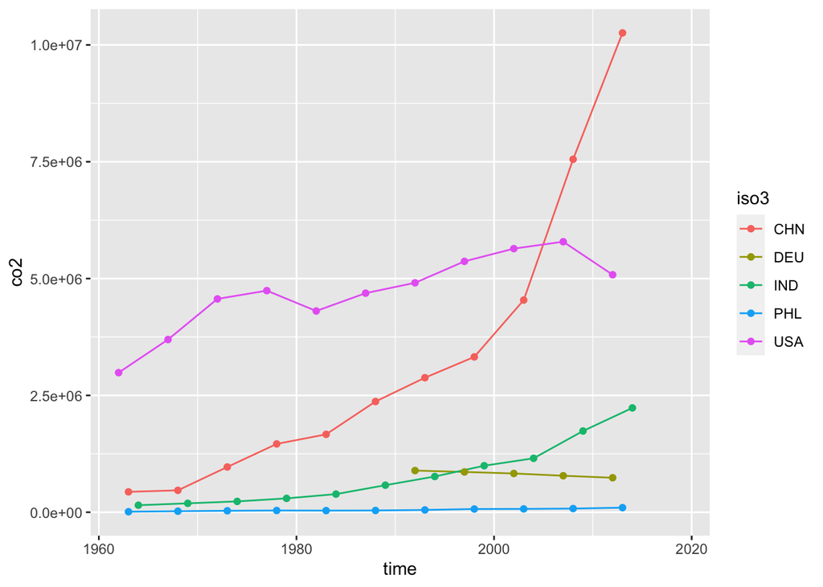

```r
#2
library(ggplot2)

gap %>%
  filter(iso3 ==c( "USA", "CHN", "IND",  "DEU", "PHL")) %>%
  ggplot()+
  geom_line(aes(x=time, y = co2, col=iso3))+
  geom_point(aes(x=time, y = co2, col=iso3))
```

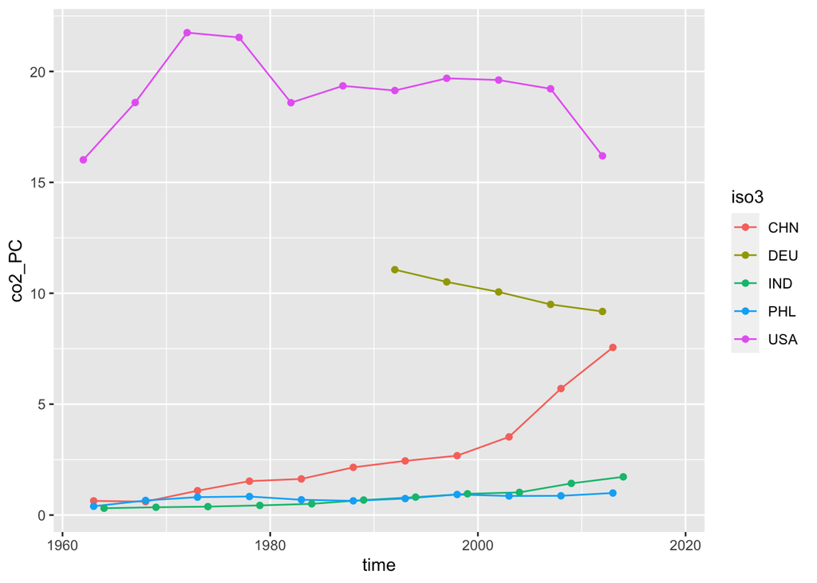

```r
#3
gap %>%
  filter(iso3 ==c( "USA", "CHN", "IND",  "DEU", "PHL")) %>%
  ggplot()+
  geom_line(aes(x=time, y = co2_PC, col=iso3))+
  geom_point(aes(x=time, y = co2_PC, col=iso3))
```

This figure for the most part tells the same story as the CO2 plot. However, India and China’s CO2 per capita are not nearly as steep, along with the data being more spread out on the plot. As the US is isolated at the top, though keeping it’s same shape.

```r
#4
co2_pc_by_continent <- gap %>%
  filter(time %in% c("1960", "2016")) %>%
  group_by(region, time) %>%
  summarize(avg_co2_pc = mean(co2_PC, na.rm = TRUE))
co2_pc_by_continent
```

```
## # A tibble: 12 × 3
## # Groups:   region [6]
##    region    time avg_co2_pc
##    <chr>    <dbl>      <dbl>
##  1 Africa    1960      0.291
##  2 Africa    2016      1.20
##  3 Americas  1960      7.15
##  4 Americas  2016      4.80
##  5 Asia      1960      1.74
##  6 Asia      2016      6.47
##  7 Europe    1960      5.77
##  8 Europe    2016      6.64
##  9 Oceania   1960      2.73
## 10 Oceania   2016      4.57
## 11 <NA>      1960    NaN
## 12 <NA>      2016     19.4
```

The output displays the average CO2 per capita levels for each continent. I presume this is the correct approach since the average for Americas matches the hint value given in the question.

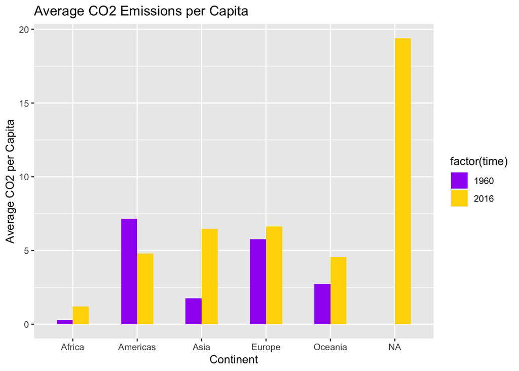

```r
#5
co2_pc_by_continent %>%
  filter(!is.na(time)) %>%
  mutate(year = as.integer(time)) %>%
  filter(year %in% c(1960, 2016)) %>%
  ggplot(aes(x = region, y = avg_co2_pc, fill = factor(time))) +
  geom_col(position = "dodge", width = 0.5) +
  scale_fill_manual(values = c("1960" = "purple", "2016" = "gold")) +
  labs(title = "Average CO2 Emissions per Capita",
       x = "Continent", y = "Average CO2 per Capita")
```

```r
#6
co2_pc_by_country_and_continent <- gap %>%
  filter(time == "2016") %>%
  group_by(region, name) %>%
  summarize(co2_pc = mean(co2_PC, na.rm = TRUE)) %>%
  arrange(region, co2_pc)
top_3_emitters <- co2_pc_by_country_and_continent %>%
  group_by(region) %>%
  slice_tail(n = 3)

bottom_3_emitters <- co2_pc_by_country_and_continent %>%
  group_by(region) %>%
  slice_head(n = 3)

top_3_emitters
```

```
## # A tibble: 16 × 3
## # Groups:   region [6]
##    region   name                       co2_pc
##    <chr>    <chr>                       <dbl>
##  1 Africa   Seychelles                   6.39
##  2 Africa   Libya                        7.79
##  3 Africa   South Africa                 8.48
##  4 Americas Saint Martin (French part) NaN
##  5 Americas Sint Maarten (Dutch part)  NaN
##  6 Americas Virgin Islands (U.S.)      NaN
##  7 Asia     Bahrain                     22.2
##  8 Asia     Kuwait                      25.0
##  9 Asia     Qatar                       38.9
## 10 Europe   Italy                      NaN
## 11 Europe   Monaco                     NaN
## 12 Europe   San Marino                 NaN
## 13 Oceania  American Samoa             NaN
## 14 Oceania  Guam                       NaN
## 15 Oceania  Northern Mariana Islands   NaN
## 16 <NA>     <NA>                        19.4
```

```r
bottom_3_emitters
```

```
## # A tibble: 16 × 3
## # Groups:   region [6]
##    region   name                               co2_pc
##    <chr>    <chr>                               <dbl>
##  1 Africa   Congo, Democratic Republic of the  0.0256
##  2 Africa   Somalia                            0.0455
##  3 Africa   Burundi                            0.0472
##  4 Americas Haiti                              0.275
##  5 Americas Nicaragua                          0.887
##  6 Americas Honduras                           1.06
##  7 Asia     Afghanistan                        0.245
##  8 Asia     Nepal                              0.334
##  9 Asia     Yemen                              0.390
## 10 Europe   Liechtenstein                      1.36
## 11 Europe   Albania                            1.58
## 12 Europe   Moldova, Republic of               1.83
## 13 Oceania  Solomon Islands                    0.272
## 14 Oceania  Vanuatu                            0.527
## 15 Oceania  Kiribati                           0.587
## 16 <NA>     <NA>                              19.4
```

I used data from 2016 instead of 2019 because in 2019, there seemed to be a lot of missing data. I checked this in the class discord and it was ok’d by Professor Ott (as long as we put a sentence about it of course).

### Section 4: GDP Per Capita

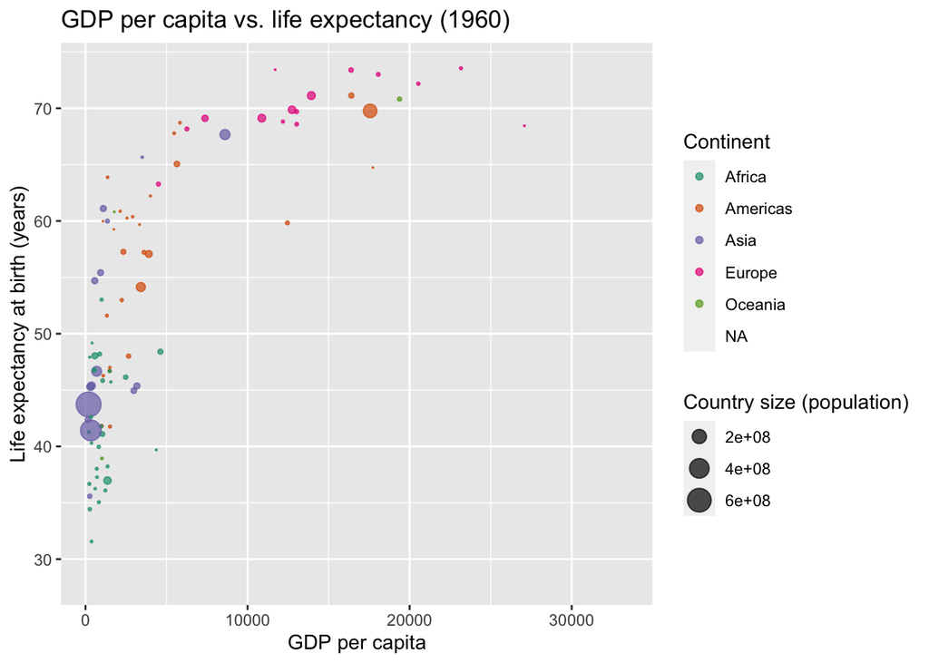

```r
#1
gap_1960 <- gap %>%
  filter(time == "1960")

ggplot(gap_1960, aes(x = GDP_PC, y = lifeExpectancy, size = totalPopulation, color = region)) +
  geom_point(alpha = 0.7) +
  scale_color_brewer(type = "qual", palette = "Dark2") +
  scale_size_area() +
  labs(x = "GDP per capita", y = "Life expectancy at birth (years)",
       size = "Country size (population)", color = "Continent", title = "GDP per capita vs. life expectancy (1960)")
```

The scatter plot shows a kinda lower case r increase with life expectancy and GDP. It looks like alo to Europe dots are on the top while on the other hand a lot of African dots are on the bottom.

[figure not shown]

```r
#2
gap_1960 <- gap %>%
  filter(time == "2019")

ggplot(gap_1960, aes(x = GDP_PC, y = lifeExpectancy, size = totalPopulation, color = region)) +
  geom_point(alpha = 0.7) +
  scale_color_brewer(type = "qual", palette = "Dark2") +
  scale_size_area() +
  labs(x = "GDP per capita", y = "Life expectancy at birth (years)",
       size = "Country size (population)", color = "Continent", title = "GDP per capita vs. life expectancy (1960)")
```

This graph dispolays the same shape and general behavior as the other one however the most notable thing is the change in the scales. Both have increased.

3.) Comparing the two plots we can ultimately see that both GDP per capita and Life Expectancy have significantly increased from 1960 to 2019. However, this makes perfect sense with knowing human advancement within these years. Especially with our furthering knowledge in technology, medical health, economic endeavors, and so on.

```r
#4
life_exp_by_continent_1960 <- gap %>%
  filter(time == "1960") %>%
  group_by(region) %>%
  summarize(avg_life_exp = mean(lifeExpectancy, na.rm = TRUE))

life_exp_by_continent_2019 <- gap %>%
  filter(time == "2019") %>%
  group_by(region) %>%
  summarize(avg_life_exp = mean(lifeExpectancy, na.rm = TRUE))

life_exp_by_continent_1960
```

```
## # A tibble: 6 × 2
##   region   avg_life_exp
##   <chr>           <dbl>
## 1 Africa           41.5
## 2 Americas         58.6
## 3 Asia             51.6
## 4 Europe           68.3
## 5 Oceania          56.4
## 6 <NA>             70.7
```

```r
life_exp_by_continent_2019
```

```
## # A tibble: 6 × 2
##   region   avg_life_exp
##   <chr>           <dbl>
## 1 Africa           64.1
## 2 Americas         75.8
## 3 Asia             74.6
## 4 Europe           79.4
## 5 Oceania          73.5
## 6 <NA>             77.8
```

Yes the results do fit with what I see in the figures, as the life expectancy for all regions in 2019 are notably higher than in 1960.

```r
#5
life_exp_by_continent_over_time <- gap %>%
  group_by(region, time) %>%
  summarize(avg_life_exp = mean(lifeExpectancy, na.rm = TRUE))
life_exp_growth <- life_exp_by_continent_over_time %>%
  group_by(region) %>%
  mutate(growth = avg_life_exp - lag(avg_life_exp))

life_exp_growth_by_continent <- life_exp_growth %>%
  group_by(region) %>%
  summarize(avg_growth = mean(growth, na.rm = TRUE)) %>%
  arrange(desc(avg_growth))

life_exp_growth_by_continent
```

```
## # A tibble: 6 × 2
##   region   avg_growth
##   <chr>         <dbl>
## 1 Asia          0.389
## 2 Africa        0.384
## 3 Americas      0.291
## 4 Oceania       0.290
## 5 Europe        0.188
## 6 <NA>          0.120
```

My output shows the average growth from highest to lowest, with Asia leading the LE growth. This again, correlates to my output in the last question, as we can that Asia has the highest numeric increase.

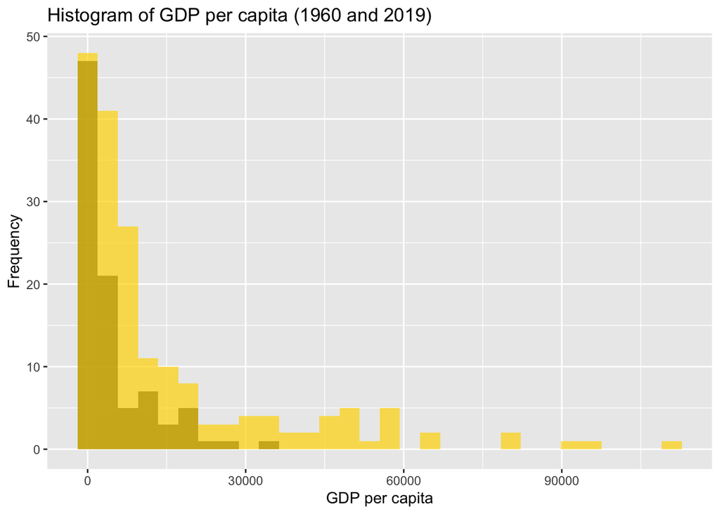

```r
#6
gap_1960 <- gap %>%
  filter(time == "1960")

gap_2019 <- gap %>%
  filter(time == "2019")

ggplot() +
  geom_histogram(data = gap_1960, aes(x = GDP_PC), fill = "black", alpha = 0.7, position = "dodge", bins = 30) +
  geom_histogram(data = gap_2019, aes(x = GDP_PC), fill = "gold", alpha = 0.7, position = "dodge", bins = 30) +
  scale_fill_manual(values = c("black", "gold")) +
  labs(x = "GDP per capita", y = "Frequency", fill = "Year", title = "Histogram of GDP per capita (1960 and 2019)") +
  theme(legend.position = "bottom")
```

In the histogram, we can observe that the 2019 data is more spread out on the graph compared to 1960. Again, this makes sense to the observations within the previous questions. I color coded 1960 to black to tell the difference between the years, despite one overlapping the other.

```r
#7
us_1960 <- gap %>%
  filter(time == "1960", iso2 == "US") %>%
  select(lifeExpectancy)

us_2019 <- gap %>%
  filter(time == "2019", iso2 == "US") %>%
  select(lifeExpectancy)

life_exp_by_country_1960 <- gap %>%
  filter(time == "1960") %>%
  arrange(desc(lifeExpectancy)) %>%
  mutate(rank = row_number())

life_exp_by_country_2019 <- gap %>%
  filter(time == "2019") %>%
  arrange(desc(lifeExpectancy)) %>%
  mutate(rank = row_number())

us_1960_rank <- life_exp_by_country_1960 %>%
  filter(lifeExpectancy == us_1960$lifeExpectancy) %>%
  select(rank)

us_2019_rank <- life_exp_by_country_2019 %>%
  filter(lifeExpectancy == us_2019$lifeExpectancy) %>%
  select(rank)

us_1960_rank
```

```
## # A tibble: 1 × 1
##    rank
##   <int>
## 1    18
```

```r
us_2019_rank
```

```
## # A tibble: 1 × 1
##    rank
##   <int>
## 1    47
```

The ranking of the US was 18th in 1960 and 47 in 2019. My output is 1 off the answer in the hint. Although, I feel like that might just be a slight data difference or something, as I don’t see/feel like I messed up on my code.

```r
#8
us_1960_rel_rank <- us_1960_rank / nrow(life_exp_by_country_1960)
us_2019_rel_rank <- us_2019_rank / nrow(life_exp_by_country_2019)

us_1960_rel_rank
```

```
##         rank
## 1 0.08333333
```

```r
us_2019_rel_rank
```

```
##        rank
## 1 0.2165899
```

Again, although my output is slightly off the hint. I feel like it just may be a slight data difference as I double checked everything and tried editing stuff within my code in the previous question and I am not finding whats giving the specific difference within my answer to the hint.

I spent about 8-9 hours on this assignment.